# Violence and disappearances in Mexico from 2018 to 2022

Anakarenina Serrano Ibarra

2024-03-22

## **Introduction**

The purpose of this research work is to analyze the relationship between reported crimes and cases of disappearances in Mexico, trying to identify geographic and demographic patterns, during the period between 2018 and 2022.For this analysis, the database *Cifras de Incidencia Delictiva Municipal del 2018 a 2022* provided by the Secretariado Ejecutivo del Sistema Nacional de Seguridad Pública (Executive Secretariat of the National System of Public Security) was implemented. In addition, the public version of the 2022 *Registro Nacional de Personas Desaparecidas y No Localizadas* (RNPDNO), provided by the National Search Commission, was included.The specific objectives of this research are oriented towards answering the following questions:

1. **Crime Incidence**: What are the crimes with the highest and lowest incidence during the period analyzed?
2. **Sex Crimes by Gender and Disappearances**: Do the top five Mexican states with the highest incidence of sex crimes coincide with the states with the highest incidence of disappearances of female individuals? Here, sexual crimes include sexual abuse, sexual harassment, sexual harassment, rape, rape and other forms of sexual violence.
3. **Demographics of Disappearances**: What is the age distribution of disappearance cases and is there a specific gender preponderance? Additionally, in the segment of children under 18 years of age, who disappears more frequently: males or females?
4. **Temporal Dynamics of Crime and Disappearances**: How do the rates of disappearances and the different types of crimes vary throughout the year? Can months be identified in which both phenomena experience an increase?
5. **Impact of Crimes against Minors on Disappearances**: Do the entities with a higher record of crimes that emphasize minors, such as trafficking of minors, corruption of minors and incest, coincide with an increase in disappearances of this same demographic group?

This analysis aims to give visibility to the complex interaction between criminality and disappearances in Mexico.

### **Data preparation**

```r
library(readr)
library(dplyr)
library(ggplot2)
library(tidyr)
library(janitor)
library(lubridate)
library(DT)
library(sf)
library(stringr)

### Import both databases needed for the analysis
setwd ("/Users/anakareninaseerr/Desktop/R Studio /EVIDENCIA 2 GABY")
violence <- read.csv("datos_violencia_municipio.csv")
disappearances <- read_csv("Desapariciones.csv", locale = locale(encoding = "ISO-8859-1"))

head(violence)
```

|  | Año | Clave_Ent | Entidad | Cve..Municipio | Municipio | Bien.jurídico.afectado | Tipo.de.delito | Subtipo.de.delito | Modalidad | Enero | Febrero | Marzo | Abril | Mayo | Junio | Julio | Agosto | Septiembre | Octubre | Noviembre | Diciembre | row_name |
| --- | --- | --- | --- | --- | --- | --- | --- | --- | --- | --- | --- | --- | --- | --- | --- | --- | --- | --- | --- | --- | --- | --- |
| 1 | 2018 | 1 | Aguascalientes | 1001 | Aguascalientes | La vida y la Integridad corporal | Homicidio | Homicidio doloso | Con arma de fuego | 4 | 3 | 3 | 3 | 3 | 1 | 1 | 2 | 4 | 2 | 4 | 3 | 1 |
| 2 | 2018 | 1 | Aguascalientes | 1001 | Aguascalientes | La vida y la Integridad corporal | Homicidio | Homicidio doloso | Con arma blanca | 1 | 0 | 1 | 0 | 2 | 0 | 0 | 0 | 1 | 0 | 1 | 0 | 2 |
| 3 | 2018 | 1 | Aguascalientes | 1001 | Aguascalientes | La vida y la Integridad corporal | Homicidio | Homicidio doloso | Con otro elemento | 2 | 3 | 0 | 2 | 2 | 3 | 0 | 1 | 0 | 1 | 0 | 0 | 3 |
| 4 | 2018 | 1 | Aguascalientes | 1001 | Aguascalientes | La vida y la Integridad corporal | Homicidio | Homicidio doloso | No especificado | 0 | 0 | 0 | 1 | 0 | 0 | 0 | 0 | 0 | 0 | 0 | 0 | 4 |
| 5 | 2018 | 1 | Aguascalientes | 1001 | Aguascalientes | La vida y la Integridad corporal | Homicidio | Homicidio culposo | Con arma de fuego | 0 | 0 | 0 | 0 | 0 | 0 | 0 | 0 | 0 | 0 | 0 | 1 | 5 |
| 6 | 2018 | 1 | Aguascalientes | 1001 | Aguascalientes | La vida y la Integridad corporal | Homicidio | Homicidio culposo | Con arma blanca | 0 | 0 | 0 | 0 | 0 | 0 | 0 | 0 | 0 | 0 | 0 | 0 | 6 |

```r
head(disappearances)
```

| Consecutivo Reportes por Persona | Consecutivo Registro | Nombre | Primer Apellido | Segundo Apellido | Edad | Sexo | Nacionalidad | Fecha de desaparición | Entidad de desaparición | Autoridad que reportó |
| --- | --- | --- | --- | --- | --- | --- | --- | --- | --- | --- |
| 1 | 1 | ALVARO RENE | ROIZ | MONCADA | 36 | HOMBRE | MEXICANA | 30/05/2022 | SINALOA | FISCALIA GENERAL DE SINALOA |
| 2 | 1 | NOEMI | LAZCANO | JACOBO | 41 | MUJER | MEXICANA | 12/12/2020 | MICHOACAN | COMISION LOCAL DE BUSQUEDA DE PERSONAS DEL ESTADO DE MICHOACAN |
| 3 | 1 | ELIMINADO 1 | ELIMINADO 1 | ELIMINADO 1 | ELIMINADO 2 | ELIMINADO 3 | ELIMINADO 4 | ELIMINADO 5 | ELIMINADO 6 | ELIMINADO 7 |
| 4 | 1 | OMAR | PEREZ | MUÑOZ | 22 | HOMBRE | MEXICANA | 22/03/2013 | TAMAULIPAS | PROCURADURIA GENERAL DE JUSTICIA DEL ESTADO DE TAMAULIPAS |
| 5 | 1 | RUFINO | GARRIDO | LINO | 58 | HOMBRE | MEXICANA | 15/04/2020 | ESTADO DE MEXICO | PARTICULAR |
| 6 | 1 | LUIS JAIME | MONTALVO | LUEVANOS | 43 | HOMBRE | MEXICANA | 01/08/2010 | TAMAULIPAS | PROCURADURIA GENERAL DE JUSTICIA DEL ESTADO DE TAMAULIPAS |

### **Data Cleaning**

```r
#Eliminate unnecessary columns in Disappearances for the analysis
disappearances_2 <- disappearances %>%
  select(-`Consecutivo Reportes por Persona`,
         -Nombre,
         -`Primer Apellido`,
         -`Segundo Apellido`,
         - Nacionalidad,
         -`Autoridad que reportó`)

#Remove unnecessary columns in Data violence for analysis
violence_2 <- violence %>%
  select(-Clave_Ent,
         -Cve..Municipio,
         -Bien.jurídico.afectado,
         -Subtipo.de.delito,
         -Modalidad,
         -Municipio,
         - row_name)

# Delete the rows with the legend "DELETED".
disappearances_clean <- disappearances_2 %>%
  filter(!if_any(everything(), ~ grepl("ELIMINADO", .x, ignore.case = TRUE)))

# Modify my db to break down "Disappearance date" into month and year (in separate columns)
disappearances_clean <- disappearances_clean %>%
  mutate(
    Fecha = dmy(`Fecha de desaparición`),
    Año = year(Fecha),
    Mes = month(Fecha, label = TRUE, abbr = FALSE) #Extract month
  ) %>%
  select(-Fecha, -`Fecha de desaparición`) #Delete the disappearance date variable
```

## **1. Crime Incidence**

```r
#### Sum all offenses and group by type
crime_type <- violence_2 %>%
  group_by(Tipo.de.delito) %>%
  summarize(Total = sum(c_across(Enero:Diciembre), na.rm = TRUE)) %>% # Add the data of the months, remove NA
  mutate(percentage = Total / sum(Total) * 100) %>% #Create a column that calculates the percentage of each type in relation to the total.
  arrange(desc(Total))

datatable(crime_type, options = list(pageLength = 5, scrollX = TRUE)) # To view the interactive tables
```

|  | Tipo.de.delito | Total | percentage |
| --- | --- | --- | --- |
| 1 | Robo | 3399938 | 33.70102816773387 |
| 2 | Violencia familiar | 1134685 | 11.24727896405908 |
| 3 | Lesiones | 1008851 | 9.999981166729064 |
| 4 | Otros delitos del Fuero Común | 893963 | 8.861182834484591 |
| 5 | Daño a la propiedad | 671251 | 6.653606288885129 |
| 6 | Amenazas | 559823 | 5.549104334239412 |
| 7 | Fraude | 415816 | 4.121671256533039 |
| 8 | Narcomenudeo | 374264 | 3.709797533416418 |
| 9 | Homicidio | 219499 | 2.175728493222352 |
| 10 | Despojo | 146206 | 1.449230110752519 |

[output cut: 30 more lines]

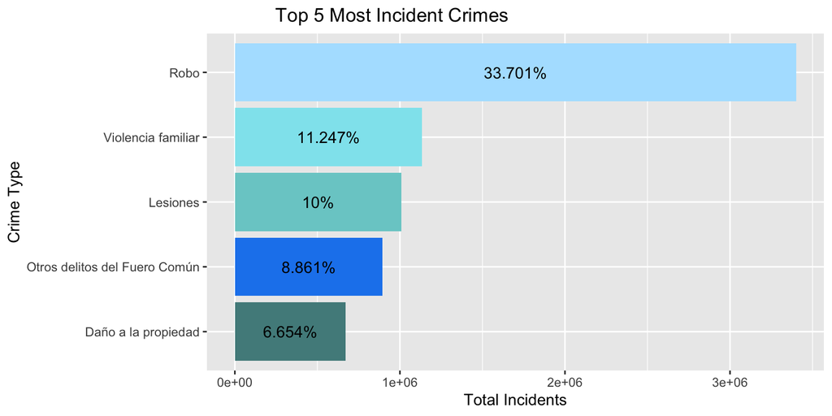

```r
#### Select the top 5 crimes with highest incidence
top5_more_incidence <- slice_max(crime_type, order_by = Total, n = 5)

#### Select the top 5 crimes with less incidence
top5_less_incidence <- slice_min(crime_type, order_by = Total, n = 5)

#### Declared colors for my graphics
color_more_incidence <- c("darkslategray4", "darkslategray3", "dodgerblue2", "lightskyblue1", "cadetblue2")
color_less_incidence <- c("thistle2", "violetred2", "orchid3", "lightpink2", "hotpink2")

#### Chart for top 5 crimes with highest incidence
ggplot(top5_more_incidence, aes(x = reorder(Tipo.de.delito, Total), y = Total, fill = Tipo.de.delito)) + # Reorder causes the crime types to be sorted by total occurrences, not alphabetically or by the original order in the dataframe.
  geom_col(show.legend = FALSE) +
  coord_flip() + # Reverse the axes
  scale_fill_manual(values = color_more_incidence) + # Customize the colors of the bars using my set
  geom_text(aes(label = paste0(round(percentage, 3), "%")), position = position_stack(vjust = 0.5), color = "black") + # paste0 pastes strings without spaces, roun is to leave 3 decimals in my %, position_stack is in charge of putting vertically centered labels on the chart.
  labs(title = "             Top 5 Most Incident Crimes", x = "Crime Type", y = "Total Incidents")
```

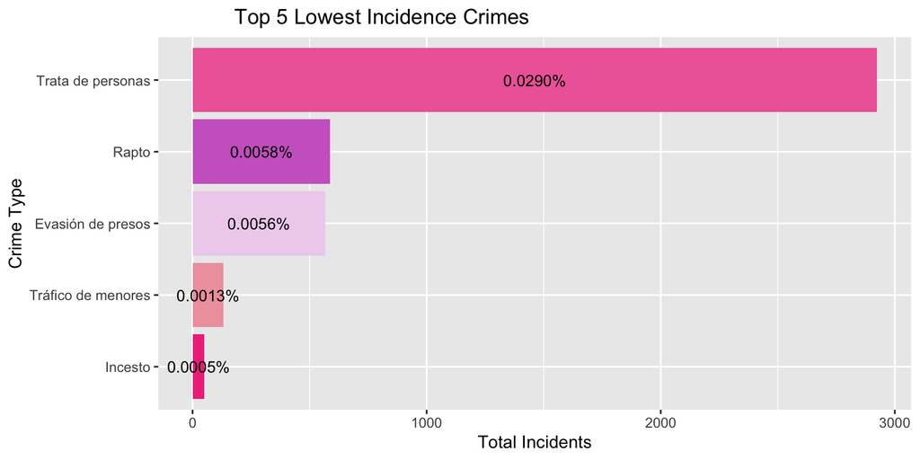

```r
# Chart for the top 5 crimes with less incidence
ggplot(top5_less_incidence, aes(x = reorder(Tipo.de.delito, Total), y = Total, fill = Tipo.de.delito)) +
  geom_col(show.legend = FALSE) +
  coord_flip() +
  scale_fill_manual(values = color_less_incidence) +
  geom_text(aes(label = sprintf("%.4f%%", percentage)), position = position_stack(vjust = 0.5), color = "black", size = 3.5) +
  labs(title = "             Top 5 Lowest Incidence Crimes", x = "Crime Type", y = "Total Incidents")
```

The data highlight the need for public security strategies in Mexico that address both high frequency crimes (robbery) and those of high severity (human trafficking), and the prevention of robbery requires increased surveillance in high-risk areas, community crime prevention programs, and strategies to address root causes such as poverty (UNODC, 2011), as well as the quality and access to data that are essential for the analysis of crime incidence. Black figures (unreported or unrecorded crimes) can affect the perception and understanding of the crime problem (IIEG, 2022).

## **2. Gender-Based Sex Crimes and Disappearances**.

```r
# Define offenses related to sexual violence
sexual_crime <- c("Abuso sexual", "Acoso sexual", "Hostigamiento sexual",
                      "Violación simple", "Violación equiparada",
                      "Otros delitos que atentan contra la libertad y la seguridad sexual",
                      "Violencia de género en todas sus modalidades distinta a la violencia familiar")

# Filter the data to include only sexual offenses and sum by entity.
sexual_crime_entity <- violence_2 %>%
  filter(Tipo.de.delito %in% sexual_crime) %>%
  filter(Entidad != "México") %>% # Excludes the entity "Mexico
  group_by(Entidad) %>%
  summarize(Total_Sexual_Crime = sum(c_across(Enero:Diciembre), na.rm = TRUE)) %>% #Add sex offenses in all months
  arrange(desc(Total_Sexual_Crime))

# Choose the top 5 entities with the highest number of incidences of sexual offences
top5_sexual_entity <- slice_max(sexual_crime_entity, order_by = Total_Sexual_Crime, n = 5)

# Upload Mexico geospatial data
mexico_map <- st_read("/Users/anakareninaseerr/Desktop/R Studio /EVIDENCIA 2 GABY/Shapefile - Estados")
```

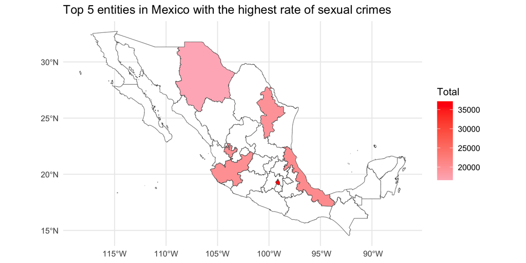

```r
# Corrected special character encoding problems for the whole column
mexico_map$nom_ent <- iconv(mexico_map$nom_ent, "latin1", "UTF-8")

# Replace the state names in mexico_map to match top5_sexual_entity
mexico_map$nom_ent <- str_replace_all(mexico_map$nom_ent, "Nuevo León", "Nuevo León")
mexico_map$nom_ent <- str_replace_all(mexico_map$nom_ent, "Distrito Federal", "Ciudad de México")
mexico_map$nom_ent <- str_replace_all(mexico_map$nom_ent, "Veracruz de Ignacio de la Llave", "Veracruz de Ignacio de la Llave")
mexico_map$nom_ent <- str_replace_all(mexico_map$nom_ent, "Jalisco", "Jalisco")
mexico_map$nom_ent <- str_replace_all(mexico_map$nom_ent, "Chihuahua", "Chihuahua")

# Make the joint
mexico_data <- left_join(mexico_map, top5_sexual_entity, by = c("nom_ent" = "Entidad"))

# Create the map
ggplot(data = mexico_data) +
  geom_sf(aes(fill = Total_Sexual_Crime)) +
  scale_fill_gradient(low = "lightpink", high = "red", na.value = "white") +
  labs(title = "Top 5 entities in Mexico with the highest rate of sexual crimes", fill = "Total") +
  theme_minimal()
```

```r
datatable(top5_sexual_entity, options = list(pageLength = 5, scrollX = TRUE))
```

|  | Entidad | Total_Sexual_Crime |
| --- | --- | --- |
| 1 | Ciudad de México | 37154 |
| 2 | Veracruz de Ignacio de la Llave | 20519 |
| 3 | Jalisco | 19941 |
| 4 | Nuevo León | 19412 |
| 5 | Chihuahua | 16611 |

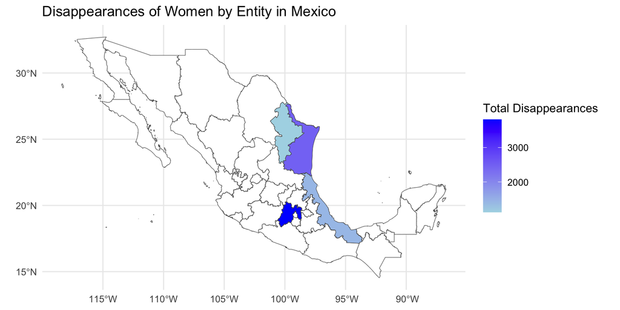

```r
# Calculation of states with the highest rate of disappearances of women
women_disappearances <- disappearances_clean %>%
  filter(Sexo == "MUJER") %>%  # Filter only the disappearances of women
  group_by(`Entidad de desaparición`) %>%
  summarise(Total_Desapariciones = n()) %>%
  arrange(desc(Total_Desapariciones))

# Choose the top 5 entities with the highest number of incidences of disappearances of women
top5_women_disappearances <- slice_max(women_disappearances, order_by = Total_Desapariciones, n = 5)

# I replace the state names in mexico_map to match top5_women_disappearances
mexico_map$nom_ent <- str_replace_all(mexico_map$nom_ent, "Nuevo León", "NUEVO LEON")
mexico_map$nom_ent <- str_replace_all(mexico_map$nom_ent, "Distrito Federal", "CIUDAD DE MEXICO")
mexico_map$nom_ent <- str_replace_all(mexico_map$nom_ent, "Veracruz de Ignacio de la Llave", "VERACRUZ")
mexico_map$nom_ent <- str_replace_all(mexico_map$nom_ent, "Tamaulipas", "TAMAULIPAS")
mexico_map$nom_ent <- str_replace_all(mexico_map$nom_ent, "México", "ESTADO DE MEXICO")

# Make the joint
mexico_data <- left_join(mexico_map, top5_women_disappearances, by = c("nom_ent" = "Entidad de desaparición"))

# Create the map
ggplot(data = mexico_data) +
  geom_sf(aes(fill = Total_Desapariciones)) +
  scale_fill_gradient(low = "lightblue", high = "blue", na.value = "white") +
  labs(title = "Disappearances of Women by Entity in Mexico", fill = "Total Disappearances") +
  theme_minimal()
```

```r
datatable(top5_women_disappearances, options = list(pageLength = 5, scrollX = TRUE))
```

|  | Entidad de desaparición | Total_Desapariciones |
| --- | --- | --- |
| 1 | ESTADO DE MEXICO | 3815 |
| 2 | TAMAULIPAS | 2474 |
| 3 | VERACRUZ | 1409 |
| 4 | CIUDAD DE MEXICO | 1240 |
| 5 | NUEVO LEON | 1120 |

The presence of Mexico City, Veracruz and Nuevo Leon in the lists of high incidence of both sexual crimes and disappearances of women highlights the urgency of exploring the causes associated with these problems, such as gender violence, socioeconomic disparities and the competence of law enforcement agencies in these territories, according to the Registro Nacional de Personas Desaparecidas y No Localizadas (UNDP) in 2022.

## **3. Demographics of Disappearances**.

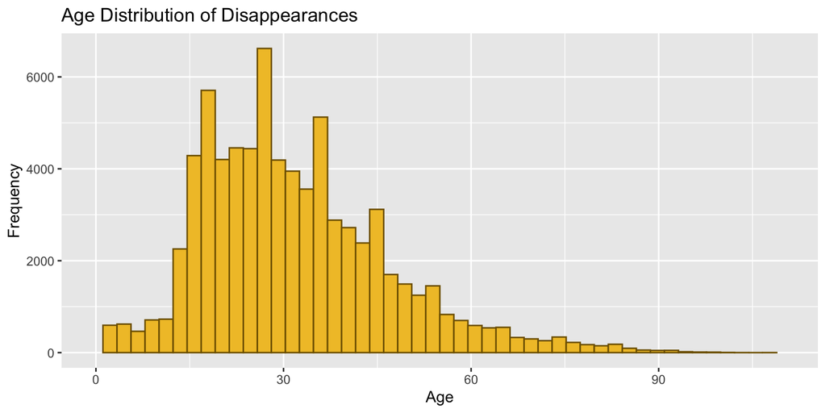

```r
# Convert "Age" to numerical
disappearances_clean$Edad <- as.numeric(disappearances_clean$Edad)

# Histogram of age distribution
ggplot(disappearances_clean, aes(x = Edad)) +
  geom_histogram(bins = 50, fill = '#F1C232', color = '#7F6000') +
  labs(title = 'Age Distribution of Disappearances', x = 'Age', y = 'Frequency') +
  xlim(0, 110)  # Sets limits for the x-axis
```

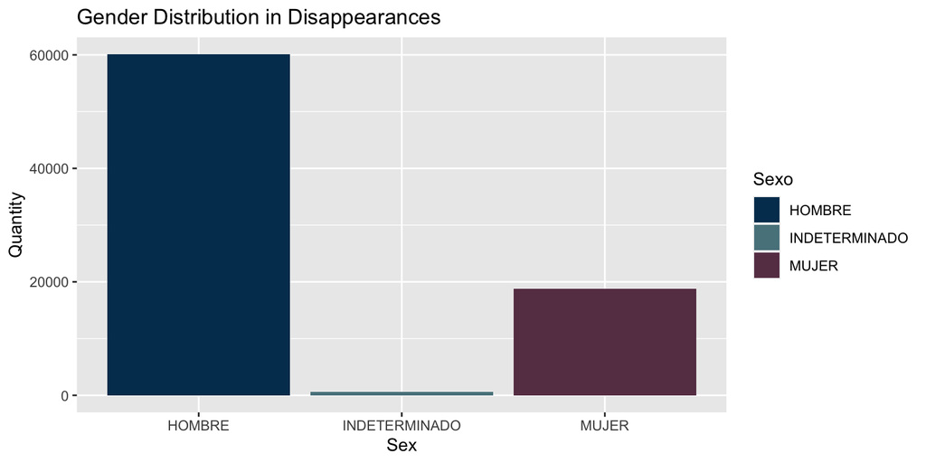

```r
# Count by sex
gender_distribution <- disappearances_clean %>%
  group_by(Sexo) %>%
  summarise(Count = n())

# Make a bar chart of the gender distribution
ggplot(gender_distribution, aes(x = Sexo, y = Count, fill = Sexo)) +
  geom_bar(stat = 'identity') +
  labs(title = 'Gender Distribution in Disappearances', x = 'Sex', y = 'Quantity') +
  scale_fill_manual(values = c("HOMBRE" = "#023b5e", "MUJER" = "#693E55", "INDETERMINADO" = "#59838C"))
```

```r
datatable(gender_distribution, options = list(pageLength = 5, scrollX = TRUE))
```

|  | Sexo | Count |
| --- | --- | --- |
| 1 | HOMBRE | 60099 |
| 2 | INDETERMINADO | 616 |
| 3 | MUJER | 18770 |

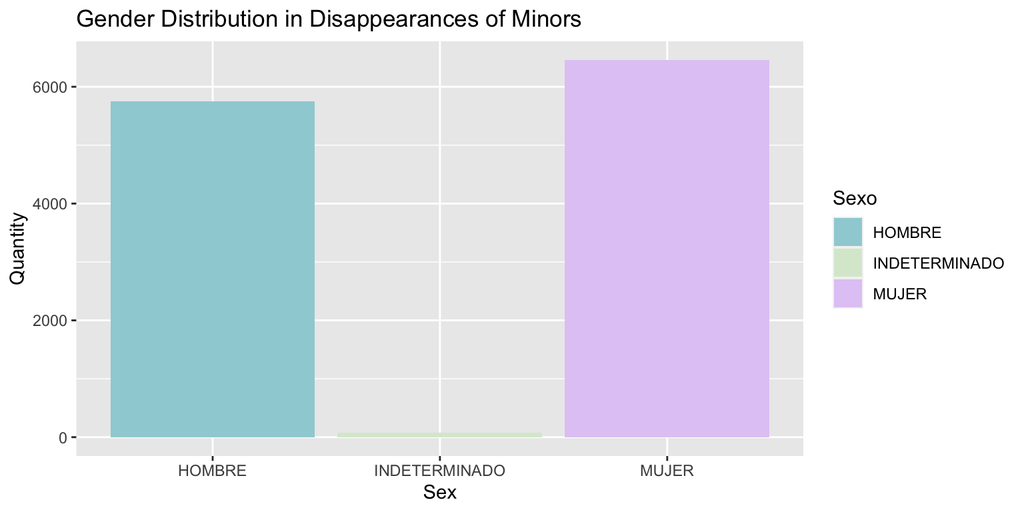

```r
# Filter under 18
minors <- disappearances_clean %>%
  filter(Edad < 18)

# Analyze the gender of minors
minors_sex <- minors %>%
  group_by(Sexo) %>%
  summarise(Count = n())

# Bar chart of the distribution of minors
ggplot(minors_sex, aes(x = Sexo, y = Count, fill = Sexo)) +
  geom_bar(stat = 'identity') +
  labs(title = 'Gender Distribution in Disappearances of Minors', x = 'Sex', y = 'Quantity') +
  scale_fill_manual(values = c("HOMBRE" = "#9FD1D7", "MUJER" = "#E2CBF5", "INDETERMINADO" = "#D9EAD3"))
```

```r
datatable(minors_sex, options = list(pageLength = 5, scrollX = TRUE))
```

|  | Sexo | Count |
| --- | --- | --- |
| 1 | HOMBRE | 5750 |
| 2 | INDETERMINADO | 74 |
| 3 | MUJER | 6457 |

From the age distribution histogram, it appears that there are a significant number of disappearances in the younger age groups, with a peak in frequency between the teens and twenties. This suggests that younger people are at a higher risk of disappearance.

In terms of gender distribution, the data provided show a higher number of disappearances of males than females. For the segment under 18 years of age, there is a higher frequency of female disappearances.

## **4. Temporal Dynamics of Crimes and Disappearances**

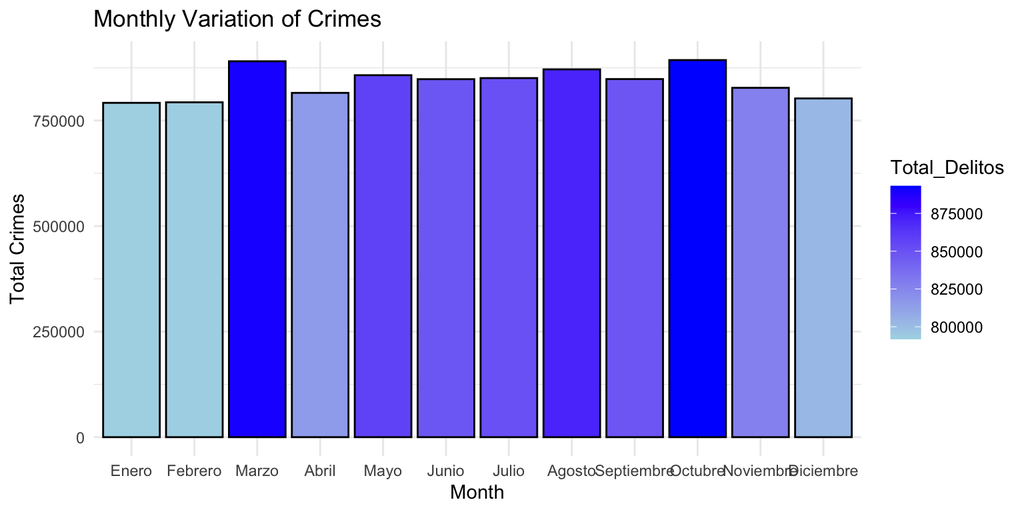

```r
# Filter data by relevant year range (2018-2022):
disappearances_clean2 <- disappearances_clean %>%
  filter(Año >= 2018 & Año <= 2022)

# Convert data from wide to long format
violence_long <- pivot_longer(violence_2,
                                     cols = Enero:Diciembre,
                                     names_to = "Mes",
                                     values_to = "Casos")

# Sort months chronologically
months_order <- c("Enero", "Febrero", "Marzo", "Abril", "Mayo", "Junio",
                 "Julio", "Agosto", "Septiembre", "Octubre", "Noviembre", "Diciembre")

months_order2 <- c("January", "February", "March", "April", "May", "June", "July", "August", "September", "October", "November", "December")

violence_long$Mes <- factor(violence_long$Mes, levels = months_order)
disappearances_clean2$Mes <- factor(disappearances_clean2$Mes, levels = months_order2)

# Sum by month and frequency
crime_month <- violence_long %>%
  group_by(Mes) %>%
  summarise(Total_Delitos = sum(Casos, na.rm = TRUE))

disappearances_month <- disappearances_clean2 %>%
  group_by(Mes) %>%
  summarise(Total_Desp = n())

# Blue Gradient Bar Crime Chart
ggplot(crime_month, aes(x = Mes, y = Total_Delitos, fill = Total_Delitos)) +
  geom_bar(stat = "identity", colour = "black") +
  labs(title = "Monthly Variation of Crimes", x = "Month", y = "Total Crimes") +
  theme_minimal() +
  scale_fill_gradient(low = "lightblue", high = "blue")
```

```r
datatable(crime_month, options = list(pageLength = 5, scrollX = TRUE))
```

|  | Mes | Total_Delitos |
| --- | --- | --- |
| 1 | Enero | 791831 |
| 2 | Febrero | 793111 |
| 3 | Marzo | 890312 |
| 4 | Abril | 815456 |
| 5 | Mayo | 857310 |
| 6 | Junio | 847920 |
| 7 | Julio | 850478 |
| 8 | Agosto | 871170 |
| 9 | Septiembre | 848123 |
| 10 | Octubre | 893133 |

[output cut: 2 more lines]

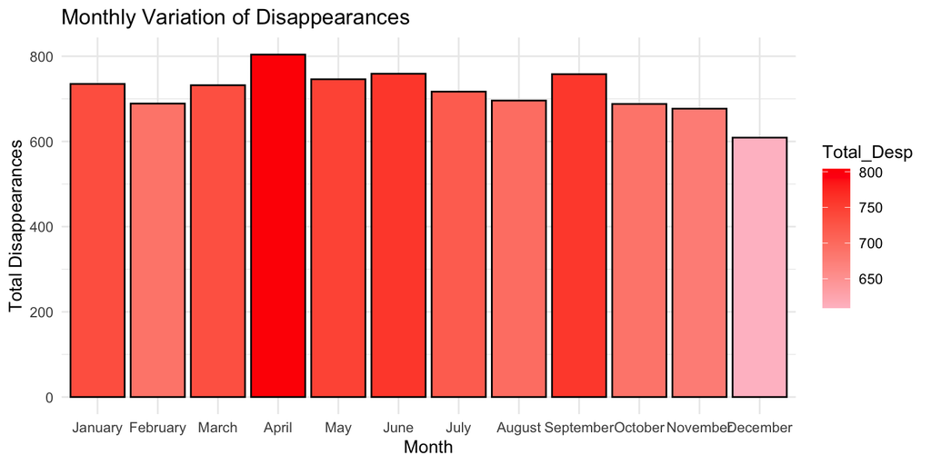

```r
# Red Gradient Bar Disappearance Chart
ggplot(disappearances_month, aes(x = Mes, y = Total_Desp, fill = Total_Desp)) +
  geom_bar(stat = "identity", colour = "black") +
  labs(title = "Monthly Variation of Disappearances", x = "Month", y = "Total Disappearances") +
  theme_minimal() +
  scale_fill_gradient(low = "pink", high = "red")
```

```r
datatable(disappearances_month, options = list(pageLength = 5, scrollX = TRUE))
```

|  | Mes | Total_Desp |
| --- | --- | --- |
| 1 | January | 735 |
| 2 | February | 689 |
| 3 | March | 732 |
| 4 | April | 804 |
| 5 | May | 746 |
| 6 | June | 759 |
| 7 | July | 717 |
| 8 | August | 696 |
| 9 | September | 758 |
| 10 | October | 688 |

[output cut: 2 more lines]

This suggests that crimes maintain a stable frequency pattern, while disappearances show greater variability throughout the year. To formulate effective prevention and intervention strategies, it is necessary to examine these patterns in conjunction with analyses of demographic, socioeconomic, and other relevant factors in order to better understand the dynamics that influence these phenomena.

## **5. Impact of Crimes against Children on Disappearances**

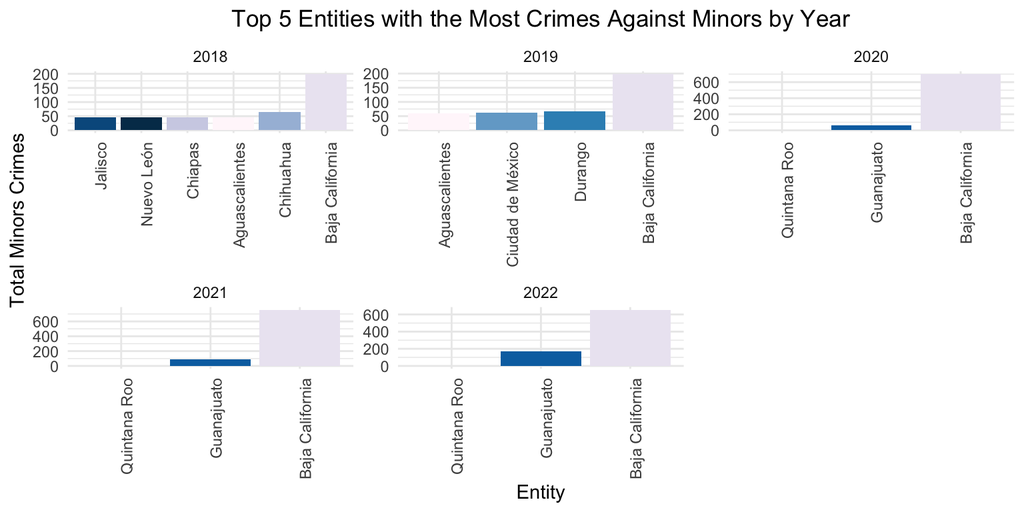

```r
# Group violence by Entity and Year to count crimes focused on minors.
minor_violence <- violence_2 %>%
  filter(Tipo.de.delito %in% c("Tráfico de menores", "Corrupción de menores", "Incesto")) %>%
  group_by(Entidad, Año) %>%
  summarise(Minor_Crime = rowSums(across(Enero:Diciembre), na.rm = TRUE))

# Obtain the top 5 entities with the most crimes focused on minors for each year
top_entity <- minor_violence %>%
  group_by(Año) %>%
  top_n(5, Minor_Crime) %>%
  ungroup() %>%
  arrange(Año, desc(Minor_Crime))

# Make the graph
ggplot(top_entity, aes(x = reorder(Entidad, Minor_Crime), y = Minor_Crime, fill = as.factor(Entidad))) +
  geom_bar(stat = "identity") +
  facet_wrap(~ Año, scales = "free") +
  theme_minimal() +
  labs(x = "Entity", y = "Total Minors Crimes", title = "Top 5 Entities with the Most Crimes Against Minors by Year") +
  theme(axis.text.x = element_text(angle = 90, hjust = 1),
        plot.title = element_text(hjust = 0.5)) +
  scale_fill_brewer(palette = "PuBu") + #Color palette
  guides(fill=FALSE)
```

```r
datatable(top_entity, options = list(pageLength = 5, scrollX = TRUE))
```

|  | Entidad | Año | Minor_Crime |
| --- | --- | --- | --- |
| 1 | Baja California | 2018 | 120 |
| 2 | Baja California | 2018 | 79 |
| 3 | Chihuahua | 2018 | 64 |
| 4 | Chiapas | 2018 | 47 |
| 5 | Aguascalientes | 2018 | 46 |
| 6 | Jalisco | 2018 | 46 |
| 7 | Nuevo León | 2018 | 46 |
| 8 | Baja California | 2019 | 109 |
| 9 | Baja California | 2019 | 89 |
| 10 | Durango | 2019 | 67 |

[output cut: 17 more lines]

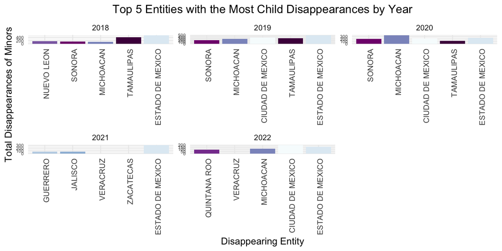

```r
# Filtering years of interest in child disappearances
disappearances_minors <- disappearances_clean %>%
  filter(Año %in% 2018:2022) %>%
  group_by(`Entidad de desaparición`, Año) %>%
  summarise(Desapariciones_Menores = n())

# Update the graph to show only the filtered years
top_entity_disappearences <- disappearances_minors %>%
  group_by(Año) %>%
  top_n(5, Desapariciones_Menores) %>%
  ungroup() %>%
  arrange(Año, desc(Desapariciones_Menores))

# Graph
ggplot(top_entity_disappearences, aes(x = reorder(`Entidad de desaparición`, Desapariciones_Menores), y = Desapariciones_Menores, fill = as.factor(`Entidad de desaparición`))) +
  geom_bar(stat = "identity") +
  facet_wrap(~ Año, scales = "free") +  # Add facet_wrap to separate by year
  theme_minimal() +
  labs(x = "Disappearing Entity", y = "Total Disappearances of Minors",
       title = "Top 5 Entities with the Most Child Disappearances by Year") +  # Updated title to reflect separation by year
  theme(axis.text.x = element_text(angle = 90, hjust = 1, vjust = 0.8),
        axis.text.y = element_text(size = rel(0.6)),
        plot.title = element_text(hjust = 0.5)) +
  scale_fill_brewer(palette = "BuPu") +
  guides(fill = FALSE)
```

```r
datatable(top_entity_disappearences, options = list(pageLength = 5, scrollX = TRUE))
```

|  | Entidad de desaparición | Año | Desapariciones_Menores |
| --- | --- | --- | --- |
| 1 | ESTADO DE MEXICO | 2018 | 528 |
| 2 | TAMAULIPAS | 2018 | 417 |
| 3 | NUEVO LEON | 2018 | 154 |
| 4 | SONORA | 2018 | 146 |
| 5 | MICHOACAN | 2018 | 120 |
| 6 | ESTADO DE MEXICO | 2019 | 493 |
| 7 | CIUDAD DE MEXICO | 2019 | 365 |
| 8 | TAMAULIPAS | 2019 | 321 |
| 9 | MICHOACAN | 2019 | 277 |
| 10 | SONORA | 2019 | 203 |

[output cut: 15 more lines]

## **Conclusions**

The study also highlighted high incidences of sex crimes and disappearances particularly in states like Mexico City, Veracruz, and Nuevo Leon, underscoring the necessity to explore socio-economic disparities and the effectiveness of law enforcement. There were discrepancies in states with high numbers of female disappearances but lower reported sexual crimes, indicating differences in crime reporting systems.

Demographically, younger age groups, particularly teens and twenties, and males in general, were more likely to disappear, though females under 18 were disappeared more frequently than males. While crime rates were relatively stable throughout the year, disappearances peaked in April, with increases also in June and September, hinting at possible seasonal and vacation-related patterns.

## **References**

Ana Isabel Meraz Espinoza. (octubre 2017). Empresas y privacidad: el cuidado de la información y los datos personales en medios digitales. Recuperado el 12 de marzo del 2024 de: https://www.redalyc.org/journal/2932/293258387016/html/

Comisión Nacional de Búsqueda de Personas. (octubre 2023). Base de datos con información individualizada de personas desaparecidas y no localizadas contenida en el Registro Nacional de Personas Desaparecidas y No Localizadas. Recuperado el 12 de marzo 2024 de: https://docs.google.com/spreadsheets/d/16kRs4GIq0NEQgxfN_Pya8LEju1PwtIPK/edit#gid=487805277

Instituto de Información Estadística y Geográfica de Jalisco. (diciembre, 2022). Cifra negra. Recuperado el 12 de marzo del 2024 de: https://iieg.gob.mx/ns/?page_id=25219

McCombs School of Business. (2021). Integrity. Recuperado el 12 de marzo del 2024 de: https://ethicsunwrapped.utexas.edu/glossary/integrity

Mónica Daniela Osorio Reyes. (diciembre 2023). Atlas de homicidios: México 2022. Recuperado el 12 de marzo 2024 de: https://www.mucd.org.mx/wp-content/uploads/2023/11/Atlas-de-homicidios-2022-Web.pdf

Oficina de las Naciones Unidas contra la Droga y el Delito. (octubre, 2011). Manual sobre la aplicación eficaz de las Directrices para la prevención del delito. Recuperado el 12 de marzo del 2024 de: https://www.unodc.org/documents/justice-and-prison-reform/crimeprevention/Handbook_on_the_Crime_Prevention_Guidelines_Spanish.pdf

Programa de las Naciones Unidas para el Desarrollo. (junio 2021). Informe Regional de Desarrollo Humano 2021. Recuperado el 12 de marzo del 2024 de: https://www.undp.org/sites/g/files/zskgke326/files/migration/latinamerica/undp-rblac-IRDH-PNUD_C04-ES.pdf

Secretariado Ejecutivo del Sistema Nacional de Seguridad Pública. (febrero 2024). Datos Abiertos de Incidencia Delictiva. Recuperado el 12 de marzo 2024 de: https://www.gob.mx/sesnsp/acciones-y-programas/datos-abiertos-de-incidencia-delictiva